# Homework_6

Erik Carlson, Emmanuel Mendez, Joe Correa, Emily Vasquez

11/8/2020

```r
acs2017_ny$LABFORCE <- as.factor(acs2017_ny$LABFORCE)
levels(acs2017_ny$LABFORCE) <- c("NA","Not in LF","in LF")

acs2017_ny$MARST <- as.factor(acs2017_ny$MARST)
levels(acs2017_ny$MARST) <- c("married spouse present","married spouse absent","separated","divorced","widowed","never married")
```

What is the difference between “NA” as label and Not in the Labor Force? Make sure you understand. (Hint, look at ages in each group). N/A means that they are under the age of 14 as they are not allowed to legally work in the United States Not in the labor force means they are not working or actively seeking for jobs. i.e A stay home mom/dad Labor force includes those between the ages of 15-65 who are either working or actively seeking jobs.

```r
acs2017_ny$age_bands <- cut(acs2017_ny$AGE,breaks=c(0,25,35,45,55,65,100))
tbl_al<-table(acs2017_ny$age_bands,acs2017_ny$LABFORCE)
tbl_al
```

```
##
##               NA Not in LF in LF
##   (0,25]   31680     11717 13256
##   (25,35]      0      4271 20523
##   (35,45]      0      4064 18924
##   (45,55]      0      5406 21747
##   (55,65]      0     10563 18106
##   (65,100]     0     28701  5880
```

From this aggregated data we wished to find the proportion of individuals in each age range that were in the labor force. We did this by making an array for each age range that calculated the proportions by selecting elements from the above table. We then created a new dataframe that used the above data to display the relevant proportions.

```r
x=c(tbl_al[1,3]/(tbl_al[1,2]+tbl_al[1,3]),
tbl_al[2,3]/(tbl_al[2,2]+tbl_al[2,3]),
tbl_al[3,3]/(tbl_al[3,2]+tbl_al[3,3]),
tbl_al[4,3]/(tbl_al[4,2]+tbl_al[4,3]),
tbl_al[5,3]/(tbl_al[5,2]+tbl_al[5,3]),
tbl_al[6,3]/(tbl_al[6,2]+tbl_al[6,3]))

age_prop_table<-data.frame(row.names=row.names(tbl_al), Prop_labor_force=x)
age_prop_table
```

```
##          Prop_labor_force
## (0,25]          0.5308133
## (25,35]         0.8277406
## (35,45]         0.8232121
## (45,55]         0.8009060
## (55,65]         0.6315532
## (65,100]        0.1700356
```

From this it can be seen that the about 63% of individuals in the age range of 55 to 65 are in the labor force. To better visualize the data it was plotted using ggplot2.

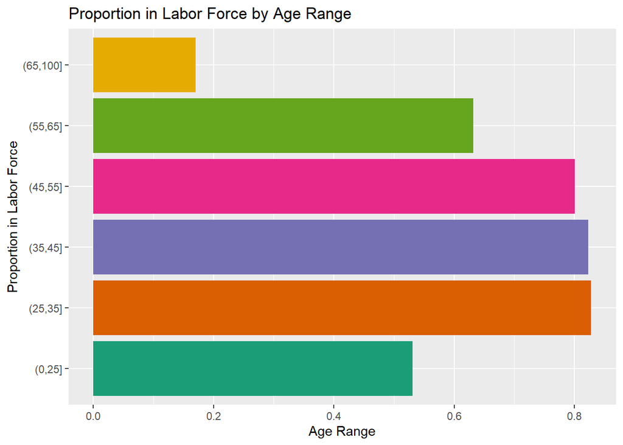

```r
ggplot(data=age_prop_table, aes(y=row.names(age_prop_table), x=Prop_labor_force, fill=row.names(age_prop_table))) +
  geom_bar(stat="identity") + scale_fill_brewer(palette = "Dark2") +ggtitle("Proportion in Labor Force by Age Range") + theme(legend.position = "none") + labs( x="Age Range", y="Proportion in Labor Force")
```

```r
#Spectral
```

It shows a trend of a lower proportion participating in age 0 to 25, made up primarily of those that are NA due to being below the requisite age of particpation. Then it maximizes in the range of 25-35 before staying near constant, but still slightly decreasing until age 55. A segment of the population exits the labor force, most likely due to retirement in the 55-65 age range, however most are still in the labor force. Then in the age range of 65-100 most individuals likely retire and exit the labor force.

```r
pick_use1 <- (acs2017_ny$AGE >25) & (acs2017_ny$AGE <= 55)
dat_use1 <- subset(acs2017_ny, pick_use1)

dat_use1$LABFORCE <- droplevels(dat_use1$LABFORCE) # actually not necessary since logit is smart enough to drop unused levels, but helps my personal sense of order
```

```r
#Using
model_logit1 <- glm(LABFORCE ~ AGE + I(AGE^2) + female + AfAm + Asian + race_oth + Hispanic
            + educ_hs + educ_somecoll + educ_college + educ_advdeg + FAMSIZE
            ,
            family = binomial, data = dat_use1)
summary(model_logit1)
```

```
##
## Call:
## glm(formula = LABFORCE ~ AGE + I(AGE^2) + female + AfAm + Asian +
##     race_oth + Hispanic + educ_hs + educ_somecoll + educ_college +
##     educ_advdeg + FAMSIZE, family = binomial, data = dat_use1)
##
## Deviance Residuals:
##     Min       1Q   Median       3Q      Max
## -2.6280   0.3457   0.4955   0.6553   1.4369
##
## Coefficients:
##                 Estimate Std. Error z value Pr(>|z|)
## (Intercept)   -0.2451623  0.2377430  -1.031 0.302444
## AGE            0.0325788  0.0120427   2.705 0.006825 **
## I(AGE^2)      -0.0004113  0.0001470  -2.798 0.005146 **
## female        -0.6745928  0.0204295 -33.021  < 2e-16 ***
## AfAm          -0.2863821  0.0275035 -10.413  < 2e-16 ***
## Asian         -0.1305968  0.0374776  -3.485 0.000493 ***
## race_oth      -0.0957544  0.0332063  -2.884 0.003931 **
## Hispanic       0.1218593  0.0312831   3.895  9.8e-05 ***
## educ_hs        0.9266151  0.0309441  29.945  < 2e-16 ***
## educ_somecoll  1.5032480  0.0349743  42.982  < 2e-16 ***
## educ_college   2.0028058  0.0370521  54.054  < 2e-16 ***
## educ_advdeg    2.4468515  0.0436390  56.070  < 2e-16 ***
## FAMSIZE        0.0664596  0.0058801  11.302  < 2e-16 ***
## ---
## Signif. codes:  0 '***' 0.001 '**' 0.01 '*' 0.05 '.' 0.1 ' ' 1
##
## (Dispersion parameter for binomial family taken to be 1)
##
##     Null deviance: 71408  on 74934  degrees of freedom
## Residual deviance: 65053  on 74922  degrees of freedom
## AIC: 65079
##
## Number of Fisher Scoring iterations: 5
```

```r
library(stargazer)
stargazer(model_logit1, type="text")
```

```
##
## =============================================
##                       Dependent variable:
##                   ---------------------------
##                            LABFORCE
## ---------------------------------------------
## AGE                        0.033***
##                             (0.012)
##
## I(AGE2)                   -0.0004***
##                            (0.0001)
##
## female                     -0.675***
##                             (0.020)
##
## AfAm                       -0.286***
##                             (0.028)
##
## Asian                      -0.131***
##                             (0.037)
##
## race_oth                   -0.096***
##                             (0.033)
##
## Hispanic                   0.122***
##                             (0.031)
##
## educ_hs                    0.927***
##                             (0.031)
##
## educ_somecoll              1.503***
##                             (0.035)
##
## educ_college               2.003***
##                             (0.037)
##
## educ_advdeg                2.447***
##                             (0.044)
##
## FAMSIZE                    0.066***
##                             (0.006)
##
## Constant                    -0.245
##                             (0.238)
##
## ---------------------------------------------
## Observations                74,935
## Log Likelihood            -32,526.320
## Akaike Inf. Crit.         65,078.650
## =============================================
## Note:             *p<0.1; **p<0.05; ***p<0.01
```

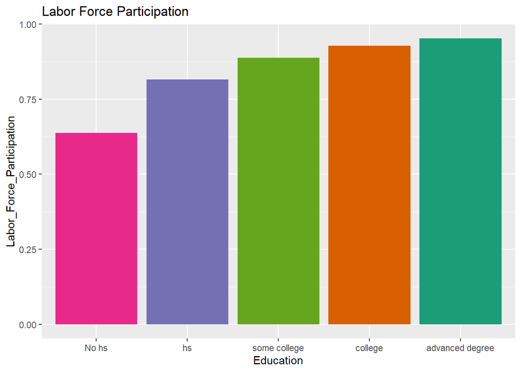

```r
nw_data2<- data.frame(AGE=30, female=0, AfAm=0, Asian=0, race_oth=0, Hispanic=0, educ_hs=0, educ_somecoll=0, educ_college=0, educ_advdeg=0,FAMSIZE=3)
nw_data3<- data.frame(AGE=30, female=0, AfAm=0, Asian=0, race_oth=0, Hispanic=0, educ_hs=1, educ_somecoll=0, educ_college=0, educ_advdeg=0,FAMSIZE=3)
nw_data4<- data.frame(AGE=30, female=0, AfAm=0, Asian=0, race_oth=0, Hispanic=0, educ_hs=0, educ_somecoll=1, educ_college=0, educ_advdeg=0,FAMSIZE=3)
nw_data5<- data.frame(AGE=30, female=0, AfAm=0, Asian=0, race_oth=0, Hispanic=0, educ_hs=0, educ_somecoll=0, educ_college=1, educ_advdeg=0,FAMSIZE=3)
nw_data6<- data.frame(AGE=30, female=0, AfAm=0, Asian=0, race_oth=0, Hispanic=0, educ_hs=0, educ_somecoll=0, educ_college=0, educ_advdeg=1,FAMSIZE=3)
total<-do.call("rbind", list(nw_data2, nw_data3, nw_data4, nw_data5, nw_data6))
total$Labor_Force_Participation<-predict(model_logit1, total, type="response")
total$education=c("No hs","hs","some college", "college", "advanced degree")

ggplot(data=total, aes(x=factor(education, level=education), y=Labor_Force_Participation, fill=education), geom="point") + geom_bar(stat="identity") + scale_fill_brewer(palette = "Dark2") + xlab("Education") + theme(legend.position = "none") + ggtitle("Labor Force Participation")
```

For a male of Age 30 of no specific race, most likely white , who is married , with a Family Size of 3, organized by education This shows us that as education increases so does labor force participation increased

```r
#Using

library(stargazer)

stargazer(model_logit1, type="text")
```

```
##
## =============================================
##                       Dependent variable:
##                   ---------------------------
##                            LABFORCE
## ---------------------------------------------
## AGE                        0.033***
##                             (0.012)
##
## I(AGE2)                   -0.0004***
##                            (0.0001)
##
## female                     -0.675***
##                             (0.020)
##
## AfAm                       -0.286***
##                             (0.028)
##
## Asian                      -0.131***
##                             (0.037)
##
## race_oth                   -0.096***
##                             (0.033)
##
## Hispanic                   0.122***
##                             (0.031)
##
## educ_hs                    0.927***
##                             (0.031)
##
## educ_somecoll              1.503***
##                             (0.035)
##
## educ_college               2.003***
##                             (0.037)
##
## educ_advdeg                2.447***
##                             (0.044)
##
## FAMSIZE                    0.066***
##                             (0.006)
##
## Constant                    -0.245
##                             (0.238)
##
## ---------------------------------------------
## Observations                74,935
## Log Likelihood            -32,526.320
## Akaike Inf. Crit.         65,078.650
## =============================================
## Note:             *p<0.1; **p<0.05; ***p<0.01
```

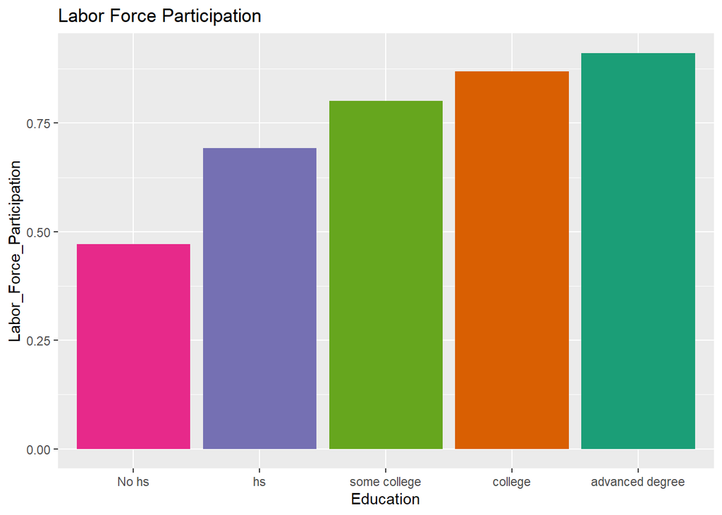

```r
nw_data2<- data.frame(AGE=30, female=1, AfAm=0, Asian=0, race_oth=0, Hispanic=0, educ_hs=0, educ_somecoll=0, educ_college=0, educ_advdeg=0,FAMSIZE=3)
nw_data3<- data.frame(AGE=30, female=1, AfAm=0, Asian=0, race_oth=0, Hispanic=0, educ_hs=1, educ_somecoll=0, educ_college=0, educ_advdeg=0,FAMSIZE=3)
nw_data4<- data.frame(AGE=30, female=1, AfAm=0, Asian=0, race_oth=0, Hispanic=0, educ_hs=0, educ_somecoll=1, educ_college=0, educ_advdeg=0,FAMSIZE=3)
nw_data5<- data.frame(AGE=30, female=1, AfAm=0, Asian=0, race_oth=0, Hispanic=0, educ_hs=0, educ_somecoll=0, educ_college=1, educ_advdeg=0,FAMSIZE=3)
nw_data6<- data.frame(AGE=30, female=1, AfAm=0, Asian=0, race_oth=0, Hispanic=0, educ_hs=0, educ_somecoll=0, educ_college=0, educ_advdeg=1,FAMSIZE=3)
total1<-do.call("rbind", list(nw_data2, nw_data3, nw_data4, nw_data5, nw_data6))
total1$Labor_Force_Participation<-predict(model_logit1, total1, type="response")
total1$education=c("No hs","hs","some college", "college", "advanced degree")

ggplot(data=total1, aes(x=factor(education, level=education), y=Labor_Force_Participation, fill=education), geom="point") + geom_bar(stat="identity") + scale_fill_brewer(palette = "Dark2") + xlab("Education") + theme(legend.position = "none") + ggtitle("Labor Force Participation")
```

For a female of Age 30 of no specific race, most likely white , who is married , with a Family Size of 3, organized by education This shows us that as education increases so does labor force participation increased, however we can observe a clear difference between labor force participation between male and female at the no HS and HS level.

```r
LF_gend<-data.frame(education=c("No hs","hs","some college", "college", "advanced degree"), Male=total$Labor_Force_Participation, Female=total1$Labor_Force_Participation, Gender_Difference=total$Labor_Force_Participation-total1$Labor_Force_Participation)
print(LF_gend)
```

```
##         education      Male    Female Gender_Difference
## 1           No hs 0.6367791 0.4717349        0.16504423
## 2              hs 0.8157819 0.6928408        0.12294114
## 3    some college 0.8874205 0.8006029        0.08681762
## 4         college 0.9285229 0.8687127        0.05981014
## 5 advanced degree 0.9529460 0.9116275        0.04131856
```

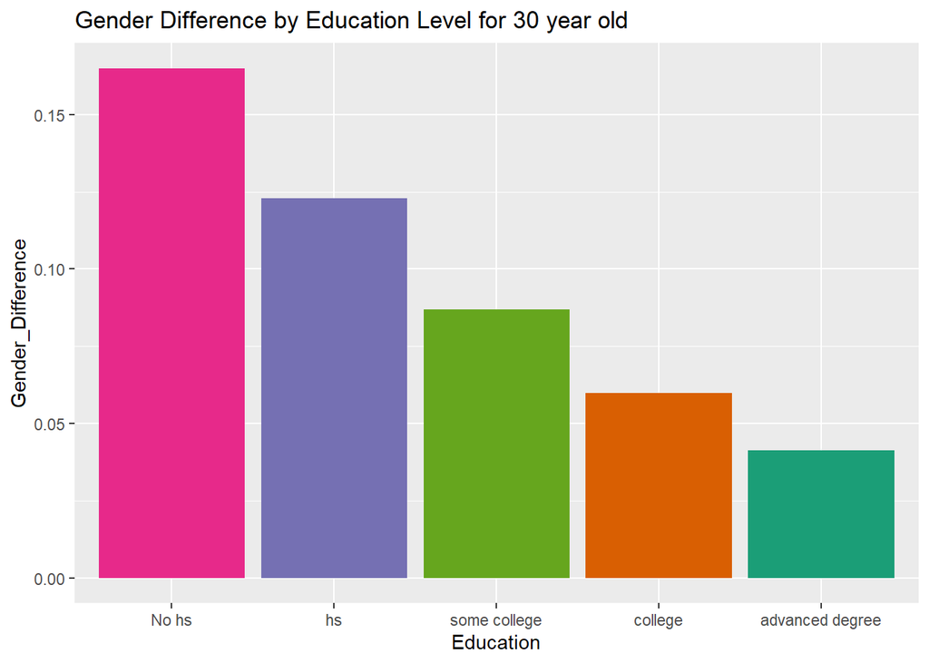

```r
ggplot(data=LF_gend, aes(x=factor(education, levels=education), y=Gender_Difference, fill=education), geom="point") + geom_bar(stat="identity") + scale_fill_brewer(palette = "Dark2") + xlab("Education") + theme(legend.position = "none") + ggtitle("Gender Difference by Education Level for 30 year old")
```

We further explore the differences mentioned above and we can clearly see the percent difference is greatest at the no HS level followed by HS level.

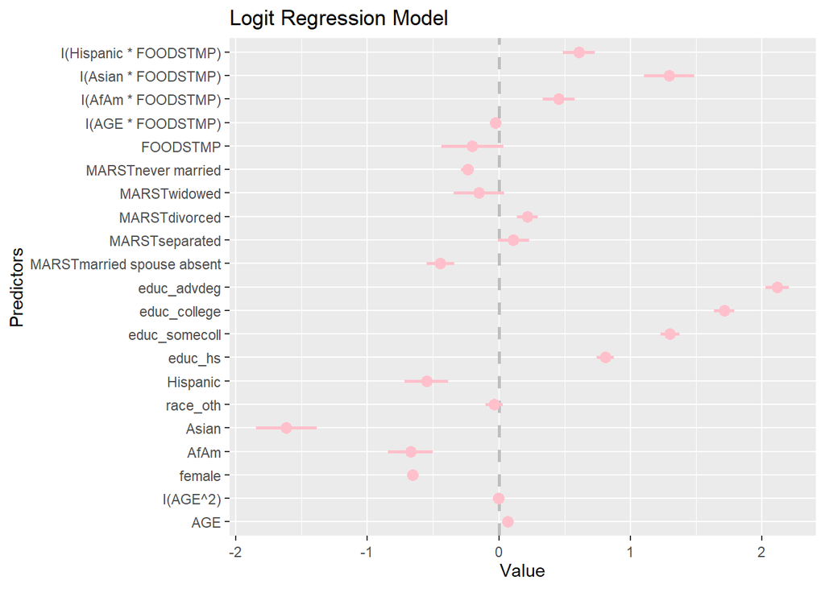

```r
#Using
model_logit1 <- glm(LABFORCE ~ AGE + I(AGE^2) + female + AfAm + Asian + race_oth + Hispanic
            + educ_hs + educ_somecoll + educ_college + educ_advdeg + MARST + FOODSTMP + I(AGE*FOODSTMP) + I(AfAm*FOODSTMP) + I(Asian*FOODSTMP) + I(Hispanic*FOODSTMP)
            ,family = binomial, data = dat_use1)

coefplot(model_logit1, innerCI=2, outerCI=0, intercept = FALSE, title = "Logit Regression Model", color = "pink", ylab = "Predictors")
```

```r
summary(model_logit1)
```

```
##
## Call:
## glm(formula = LABFORCE ~ AGE + I(AGE^2) + female + AfAm + Asian +
##     race_oth + Hispanic + educ_hs + educ_somecoll + educ_college +
##     educ_advdeg + MARST + FOODSTMP + I(AGE * FOODSTMP) + I(AfAm *
##     FOODSTMP) + I(Asian * FOODSTMP) + I(Hispanic * FOODSTMP),
##     family = binomial, data = dat_use1)
##
## Deviance Residuals:
##     Min       1Q   Median       3Q      Max
## -2.6309   0.3478   0.4800   0.6175   1.8712
##
## Coefficients:
##                              Estimate Std. Error z value Pr(>|z|)
## (Intercept)                 0.5053745  0.2891329   1.748 0.080482 .
## AGE                         0.0656579  0.0128230   5.120 3.05e-07 ***
## I(AGE^2)                   -0.0005531  0.0001494  -3.702 0.000214 ***
## female                     -0.6561690  0.0208306 -31.500  < 2e-16 ***
## AfAm                       -0.6707036  0.0846153  -7.927 2.25e-15 ***
## Asian                      -1.6140419  0.1151056 -14.022  < 2e-16 ***
## race_oth                   -0.0345402  0.0333249  -1.036 0.299983
## Hispanic                   -0.5501684  0.0838629  -6.560 5.37e-11 ***
## educ_hs                     0.8089218  0.0317762  25.457  < 2e-16 ***
## educ_somecoll               1.2993012  0.0359143  36.178  < 2e-16 ***
## educ_college                1.7118365  0.0381600  44.859  < 2e-16 ***
## educ_advdeg                 2.1158295  0.0447895  47.239  < 2e-16 ***
## MARSTmarried spouse absent -0.4434465  0.0523169  -8.476  < 2e-16 ***
## MARSTseparated              0.1100173  0.0596697   1.844 0.065217 .
## MARSTdivorced               0.2167474  0.0388674   5.577 2.45e-08 ***
## MARSTwidowed               -0.1516370  0.0962387  -1.576 0.115110
## MARSTnever married         -0.2369780  0.0247538  -9.573  < 2e-16 ***
## FOODSTMP                   -0.2010967  0.1177176  -1.708 0.087581 .
## I(AGE * FOODSTMP)          -0.0251105  0.0027501  -9.131  < 2e-16 ***
## I(AfAm * FOODSTMP)          0.4547490  0.0611743   7.434 1.06e-13 ***
## I(Asian * FOODSTMP)         1.2944717  0.0951081  13.611  < 2e-16 ***
## I(Hispanic * FOODSTMP)      0.6063994  0.0605340  10.017  < 2e-16 ***
## ---
## Signif. codes:  0 '***' 0.001 '**' 0.01 '*' 0.05 '.' 0.1 ' ' 1
##
## (Dispersion parameter for binomial family taken to be 1)
##
##     Null deviance: 71408  on 74934  degrees of freedom
## Residual deviance: 63391  on 74913  degrees of freedom
## AIC: 63435
##
## Number of Fisher Scoring iterations: 5
```

For the ages on 25-55 we look at individual as well as different interactions based on race, education, marriage status and whether or no specific races have food stamps. We find that females in general are significantly less likely to be in the labor force than men Asian women are even less likely to be in the labor force , this may be due to cultural differences

Martial status , the only significant correlation between your martial status and your participation in the labor force is found if your spouse is absent, you are divorced or never married.

```r
model_logit1 <- glm(LABFORCE ~ AGE + I(AGE^2) + I(female*AfAm) +I(female*Asian) + I(female*race_oth) + I(female*Hispanic) + female + AfAm + Asian + race_oth + Hispanic
            + educ_hs + educ_somecoll + educ_college + educ_advdeg
            + MARST,
            family = binomial, data = dat_use1)

summary(model_logit1)
```

```
##
## Call:
## glm(formula = LABFORCE ~ AGE + I(AGE^2) + I(female * AfAm) +
##     I(female * Asian) + I(female * race_oth) + I(female * Hispanic) +
##     female + AfAm + Asian + race_oth + Hispanic + educ_hs + educ_somecoll +
##     educ_college + educ_advdeg + MARST, family = binomial, data = dat_use1)
##
## Deviance Residuals:
##     Min       1Q   Median       3Q      Max
## -2.6899   0.3303   0.4890   0.6496   1.6524
##
## Coefficients:
##                              Estimate Std. Error z value Pr(>|z|)
## (Intercept)                 0.7046949  0.2461423   2.863 0.004197 **
## AGE                         0.0160542  0.0121599   1.320 0.186749
## I(AGE^2)                   -0.0003090  0.0001477  -2.092 0.036474 *
## I(female * AfAm)            1.0695988  0.0550279  19.437  < 2e-16 ***
## I(female * Asian)          -0.6155831  0.0815278  -7.551 4.33e-14 ***
## I(female * race_oth)       -0.0609912  0.0694674  -0.878 0.379953
## I(female * Hispanic)       -0.0611090  0.0624557  -0.978 0.327858
## female                     -0.7913014  0.0270458 -29.258  < 2e-16 ***
## AfAm                       -0.7623921  0.0395850 -19.260  < 2e-16 ***
## Asian                       0.3042905  0.0676119   4.501 6.78e-06 ***
## race_oth                   -0.0347939  0.0553227  -0.629 0.529397
## Hispanic                    0.1975645  0.0487992   4.049 5.15e-05 ***
## educ_hs                     0.9028419  0.0313028  28.842  < 2e-16 ***
## educ_somecoll               1.4496726  0.0353036  41.063  < 2e-16 ***
## educ_college                1.9444778  0.0373725  52.030  < 2e-16 ***
## educ_advdeg                 2.3743143  0.0440103  53.949  < 2e-16 ***
## MARSTmarried spouse absent -0.5425750  0.0520198 -10.430  < 2e-16 ***
## MARSTseparated             -0.1449673  0.0578260  -2.507 0.012178 *
## MARSTdivorced               0.0586915  0.0376972   1.557 0.119490
## MARSTwidowed               -0.3145046  0.0934818  -3.364 0.000767 ***
## MARSTnever married         -0.4011838  0.0242404 -16.550  < 2e-16 ***
## ---
## Signif. codes:  0 '***' 0.001 '**' 0.01 '*' 0.05 '.' 0.1 ' ' 1
##
## (Dispersion parameter for binomial family taken to be 1)
##
##     Null deviance: 71408  on 74934  degrees of freedom
## Residual deviance: 64300  on 74914  degrees of freedom
## AIC: 64342
##
## Number of Fisher Scoring iterations: 5
```

```r
#model_v1 <- lm(INCWAGE ~ AGE, data = acs2017_ny)
model_logit3 <- glm(LABFORCE ~ AGE +  I(AGE^2) + educ_hs + educ_somecoll + educ_college + educ_advdeg + NCHILD + FOODSTMP + I(NCHILD*FOODSTMP) + I(AfAm*FOODSTMP) + I(HISPAN*FOODSTMP) + I(below_povertyline*FOODSTMP) + I(below_150poverty*FOODSTMP) + I(below_200poverty*FOODSTMP), family = binomial, data = dat_use1)

summary(model_logit3)
```

```
##
## Call:
## glm(formula = LABFORCE ~ AGE + I(AGE^2) + educ_hs + educ_somecoll +
##     educ_college + educ_advdeg + NCHILD + FOODSTMP + I(NCHILD *
##     FOODSTMP) + I(AfAm * FOODSTMP) + I(HISPAN * FOODSTMP) + I(below_povertyline *
##     FOODSTMP) + I(below_150poverty * FOODSTMP) + I(below_200poverty *
##     FOODSTMP), family = binomial, data = dat_use1)
##
## Deviance Residuals:
##     Min       1Q   Median       3Q      Max
## -2.7539   0.3674   0.4572   0.6017   2.0315
##
## Coefficients:
##                                   Estimate Std. Error z value Pr(>|z|)
## (Intercept)                      0.2985402  0.2554599   1.169  0.24255
## AGE                              0.0494918  0.0127950   3.868  0.00011 ***
## I(AGE^2)                        -0.0006973  0.0001558  -4.476 7.61e-06 ***
## educ_hs                          0.6940742  0.0326864  21.234  < 2e-16 ***
## educ_somecoll                    1.0622637  0.0365891  29.032  < 2e-16 ***
## educ_college                     1.3718185  0.0388217  35.336  < 2e-16 ***
## educ_advdeg                      1.7384208  0.0451193  38.529  < 2e-16 ***
## NCHILD                          -0.3747023  0.0251939 -14.873  < 2e-16 ***
## FOODSTMP                        -0.2038235  0.0423071  -4.818 1.45e-06 ***
## I(NCHILD * FOODSTMP)             0.3506024  0.0189823  18.470  < 2e-16 ***
## I(AfAm * FOODSTMP)              -0.0365376  0.0215907  -1.692  0.09059 .
## I(HISPAN * FOODSTMP)             0.0583132  0.0065961   8.841  < 2e-16 ***
## I(below_povertyline * FOODSTMP) -0.5288004  0.0267828 -19.744  < 2e-16 ***
## I(below_150poverty * FOODSTMP)  -0.3780089  0.0355961 -10.619  < 2e-16 ***
## I(below_200poverty * FOODSTMP)  -0.2981230  0.0313435  -9.511  < 2e-16 ***
## ---
## Signif. codes:  0 '***' 0.001 '**' 0.01 '*' 0.05 '.' 0.1 ' ' 1
##
## (Dispersion parameter for binomial family taken to be 1)
##
##     Null deviance: 71408  on 74934  degrees of freedom
## Residual deviance: 61607  on 74920  degrees of freedom
## AIC: 61637
##
## Number of Fisher Scoring iterations: 5
```

Here our variables are education, number of children , food stamps, and placement in the poverty line.

```r
#What other subsets? What changes about results with different subsets?

#For homework, I will ask for predicted values so you can start to figure out how to get those.

#Do the X variables have the expected signs and patterns of significance?

pick_use2 <- (acs2017_ny$AGE > 25) & (acs2017_ny$AGE < 55) & (acs2017_ny$has_AnyHealthIns == 1)
dat_use2 <- subset(acs2017_ny, pick_use2)

dat_use2$LABFORCE <- droplevels(dat_use2$LABFORCE) # actually not necessary since logit is smart enough to drop unused levels, but helps Dean Foster's personal sense of order

#model_v2 <- lm(INCWAGE ~ AGE, data = acs2017_ny)
model_logit2 <- glm(LABFORCE ~ AGE +  I(AGE^2) + educ_hs + educ_somecoll + educ_college + educ_advdeg + FOODSTMP + AfAm + HISPAN + I(AfAm*FOODSTMP) + I(HISPAN*FOODSTMP) + I(below_povertyline*FOODSTMP) + I(below_150poverty*FOODSTMP) + I(below_200poverty*FOODSTMP), family = binomial, data = dat_use2)

summary(model_logit2)
```

```
##
## Call:
## glm(formula = LABFORCE ~ AGE + I(AGE^2) + educ_hs + educ_somecoll +
##     educ_college + educ_advdeg + FOODSTMP + AfAm + HISPAN + I(AfAm *
##     FOODSTMP) + I(HISPAN * FOODSTMP) + I(below_povertyline *
##     FOODSTMP) + I(below_150poverty * FOODSTMP) + I(below_200poverty *
##     FOODSTMP), family = binomial, data = dat_use2)
##
## Deviance Residuals:
##     Min       1Q   Median       3Q      Max
## -2.5984   0.3571   0.4414   0.5782   1.8947
##
## Coefficients:
##                                   Estimate Std. Error z value Pr(>|z|)
## (Intercept)                      0.2488934  0.2851132   0.873 0.382683
## AGE                              0.0433730  0.0142321   3.048 0.002307 **
## I(AGE^2)                        -0.0006483  0.0001754  -3.696 0.000219 ***
## educ_hs                          0.7448519  0.0369386  20.165  < 2e-16 ***
## educ_somecoll                    1.1185628  0.0408985  27.350  < 2e-16 ***
## educ_college                     1.4197744  0.0433165  32.777  < 2e-16 ***
## educ_advdeg                      1.7690486  0.0495065  35.734  < 2e-16 ***
## FOODSTMP                         0.0043170  0.0458884   0.094 0.925049
## AfAm                            -0.2886351  0.0948762  -3.042 0.002348 **
## HISPAN                          -0.1304127  0.0288606  -4.519 6.22e-06 ***
## I(AfAm * FOODSTMP)               0.2070605  0.0687768   3.011 0.002607 **
## I(HISPAN * FOODSTMP)             0.1536982  0.0214028   7.181 6.91e-13 ***
## I(below_povertyline * FOODSTMP) -0.4694851  0.0281634 -16.670  < 2e-16 ***
## I(below_150poverty * FOODSTMP)  -0.3442638  0.0376772  -9.137  < 2e-16 ***
## I(below_200poverty * FOODSTMP)  -0.3475192  0.0335267 -10.365  < 2e-16 ***
## ---
## Signif. codes:  0 '***' 0.001 '**' 0.01 '*' 0.05 '.' 0.1 ' ' 1
##
## (Dispersion parameter for binomial family taken to be 1)
##
##     Null deviance: 61333  on 66331  degrees of freedom
## Residual deviance: 52771  on 66317  degrees of freedom
## AIC: 52801
##
## Number of Fisher Scoring iterations: 5
```

We adjusted the subset by adding health insurance We now evaluate labor force participation based on eduaction level , foodstamp use in the last 12 months, race ( african american or hispanic) , and placement in th poverty line. We continue to see the similar trend where as your education increases so does your labor force participation.

```r
model_probit2 <- glm(LABFORCE ~ AGE +  I(AGE^2) + educ_hs + educ_somecoll + educ_college + educ_advdeg + FOODSTMP + I(AfAm*FOODSTMP) + I(HISPAN*FOODSTMP) + I(below_povertyline*FOODSTMP) + I(below_150poverty*FOODSTMP) + I(below_200poverty*FOODSTMP), family = binomial (link= 'probit'), data = dat_use2)

summary(model_probit2)
```

```
##
## Call:
## glm(formula = LABFORCE ~ AGE + I(AGE^2) + educ_hs + educ_somecoll +
##     educ_college + educ_advdeg + FOODSTMP + I(AfAm * FOODSTMP) +
##     I(HISPAN * FOODSTMP) + I(below_povertyline * FOODSTMP) +
##     I(below_150poverty * FOODSTMP) + I(below_200poverty * FOODSTMP),
##     family = binomial(link = "probit"), data = dat_use2)
##
## Deviance Residuals:
##     Min       1Q   Median       3Q      Max
## -2.5801   0.3522   0.4370   0.5837   1.8505
##
## Coefficients:
##                                   Estimate Std. Error z value Pr(>|z|)
## (Intercept)                      2.009e-01  1.567e-01   1.282  0.19970
## AGE                              2.041e-02  7.840e-03   2.603  0.00923 **
## I(AGE^2)                        -3.132e-04  9.675e-05  -3.237  0.00121 **
## educ_hs                          4.478e-01  2.208e-02  20.282  < 2e-16 ***
## educ_somecoll                    6.625e-01  2.394e-02  27.672  < 2e-16 ***
## educ_college                     8.224e-01  2.473e-02  33.250  < 2e-16 ***
## educ_advdeg                      1.001e+00  2.705e-02  36.992  < 2e-16 ***
## FOODSTMP                         2.925e-02  2.354e-02   1.243  0.21392
## I(AfAm * FOODSTMP)               5.373e-03  1.322e-02   0.406  0.68444
## I(HISPAN * FOODSTMP)             3.419e-02  4.091e-03   8.357  < 2e-16 ***
## I(below_povertyline * FOODSTMP) -2.856e-01  1.707e-02 -16.729  < 2e-16 ***
## I(below_150poverty * FOODSTMP)  -2.018e-01  2.214e-02  -9.116  < 2e-16 ***
## I(below_200poverty * FOODSTMP)  -1.936e-01  1.904e-02 -10.168  < 2e-16 ***
## ---
## Signif. codes:  0 '***' 0.001 '**' 0.01 '*' 0.05 '.' 0.1 ' ' 1
##
## (Dispersion parameter for binomial family taken to be 1)
##
##     Null deviance: 61333  on 66331  degrees of freedom
## Residual deviance: 52737  on 66319  degrees of freedom
## AIC: 52763
##
## Number of Fisher Scoring iterations: 5
```

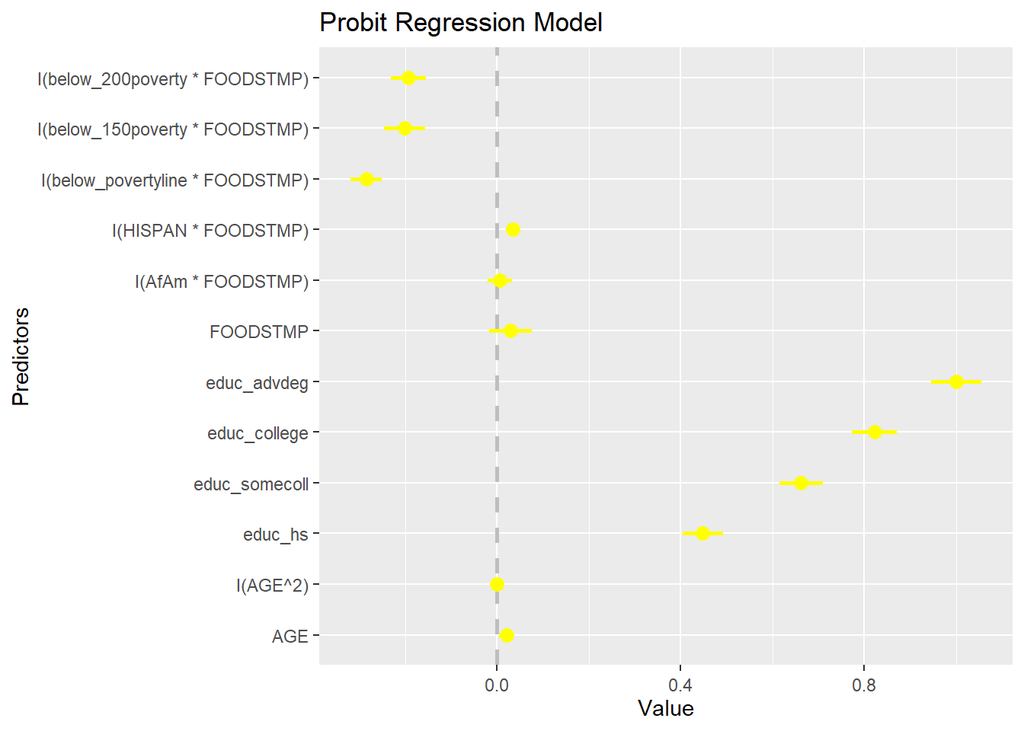

```r
#,
nw_data<- data.frame(AGE=25:55,  educ_hs=0, educ_somecoll=0, educ_college=0, educ_advdeg=0 , FOODSTMP=1, AfAm=0 , HISPAN=1, below_povertyline=0,below_150poverty=0, below_200poverty=0)

nw_data$yhat<-predict(model_probit2, nw_data, type="response")
#lines(yhat ~ AGE, data=nw_data)

coefplot(model_probit2, innerCI=2, outerCI=0, intercept = FALSE, title = "Probit Regression Model", color = "yellow", ylab = "Predictors")
```

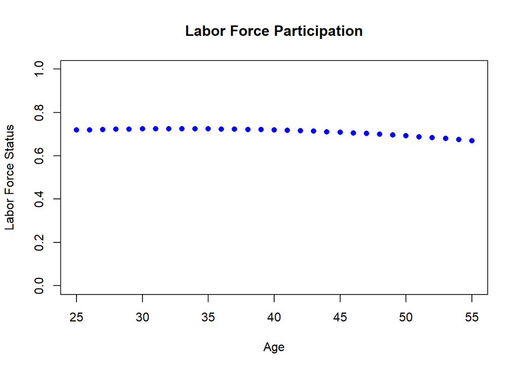

```r
plot(nw_data$yhat ~nw_data$AGE , pch = 16, ylim = c(0,1), main = "Labor Force Participation", xlab = "Age", ylab = "Labor Force Status", col = "blue")
```

```r
nw_data2<- data.frame(AGE=30, educ_hs=1, educ_somecoll=0, educ_college=0, educ_advdeg=0, FOODSTMP=2, AfAm=0 , HISPAN=0, below_povertyline=0,below_150poverty=0, below_200poverty=0)
nw_data3<- data.frame(AGE=30, educ_hs=1, educ_somecoll=0, educ_college=0, educ_advdeg=0, FOODSTMP=2, AfAm=0 , HISPAN=0, below_povertyline=0,below_150poverty=0, below_200poverty=1)
nw_data4<- data.frame(AGE=30, educ_hs=1, educ_somecoll=0, educ_college=0, educ_advdeg=0, FOODSTMP=2, AfAm=0 , HISPAN=0, below_povertyline=0,below_150poverty=1, below_200poverty=0)
nw_data5<- data.frame(AGE=30, educ_hs=1, educ_somecoll=0, educ_college=0, educ_advdeg=0, FOODSTMP=2, AfAm=0 , HISPAN=0, below_povertyline=1,below_150poverty=0, below_200poverty=0)


total2<-do.call("rbind", list(nw_data2, nw_data3, nw_data4, nw_data5))
total2$Labor_Force_Participation<-predict(model_probit2, total2, type="response")
total2$Income_Poverty_Line=c("Above 200% Poverty Line","Below 200% Poverty Line","Below 150% Poverty Line", "Below Poverty Line")
print(total2)
```

```
##   AGE educ_hs educ_somecoll educ_college educ_advdeg FOODSTMP AfAm HISPAN
## 1  30       1             0            0           0        2    0      0
## 2  30       1             0            0           0        2    0      0
## 3  30       1             0            0           0        2    0      0
## 4  30       1             0            0           0        2    0      0
##   below_povertyline below_150poverty below_200poverty Labor_Force_Participation
## 1                 0                0                0                 0.8502978
## 2                 0                0                1                 0.7423462
## 3                 0                1                0                 0.7369828
## 4                 1                0                0                 0.6795573
##       Income_Poverty_Line
## 1 Above 200% Poverty Line
## 2 Below 200% Poverty Line
## 3 Below 150% Poverty Line
## 4      Below Poverty Line
```

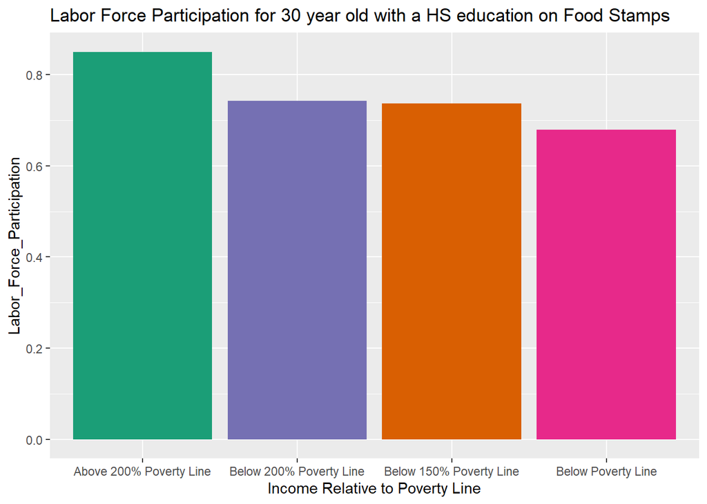

```r
ggplot(data=total2, aes(x=factor(Income_Poverty_Line, level=Income_Poverty_Line), y=Labor_Force_Participation, fill=Income_Poverty_Line), geom="point") + geom_bar(stat="identity") + scale_fill_brewer(palette = "Dark2") + xlab("Income Relative to Poverty Line") + theme(legend.position = "none") + ggtitle("Labor Force Participation for 30 year old with a HS education on Food Stamps")
```

In this data we can observe that as you have a higher income relative to the poverty line you have a higher likelihood of being in the labor force. This also shows predicted values for this group of individuals.

```r
# Explain if there is a plausible causal link from X variables to Y and not the reverse. Explain your results, giving details about the estimation, some predicted values, and providing any relevant graphics. Impress.

model_probit4 <- glm(educ_advdeg ~ as.factor(LABFORCE), family = binomial (link= 'probit'), data = dat_use2)
summary(model_probit4)
```

```
##
## Call:
## glm(formula = educ_advdeg ~ as.factor(LABFORCE), family = binomial(link = "probit"),
##     data = dat_use2)
##
## Deviance Residuals:
##     Min       1Q   Median       3Q      Max
## -0.6922  -0.6922  -0.6922  -0.4000   2.2651
##
## Coefficients:
##                          Estimate Std. Error z value Pr(>|z|)
## (Intercept)              -1.42626    0.01718  -83.01   <2e-16 ***
## as.factor(LABFORCE)in LF  0.63033    0.01821   34.62   <2e-16 ***
## ---
## Signif. codes:  0 '***' 0.001 '**' 0.01 '*' 0.05 '.' 0.1 ' ' 1
##
## (Dispersion parameter for binomial family taken to be 1)
##
##     Null deviance: 64376  on 66331  degrees of freedom
## Residual deviance: 63013  on 66330  degrees of freedom
## AIC: 63017
##
## Number of Fisher Scoring iterations: 4
```

```r
model_probit5 <- glm(as.factor(FOODSTMP) ~ LABFORCE, family = binomial (link= 'probit'), data = dat_use2)
summary(model_probit5)
```

```
##
## Call:
## glm(formula = as.factor(FOODSTMP) ~ LABFORCE, family = binomial(link = "probit"),
##     data = dat_use2)
##
## Deviance Residuals:
##     Min       1Q   Median       3Q      Max
## -0.8750  -0.4593  -0.4593  -0.4593   2.1454
##
## Coefficients:
##               Estimate Std. Error z value Pr(>|z|)
## (Intercept)   -0.47312    0.01215  -38.94   <2e-16 ***
## LABFORCEin LF -0.80775    0.01417  -56.98   <2e-16 ***
## ---
## Signif. codes:  0 '***' 0.001 '**' 0.01 '*' 0.05 '.' 0.1 ' ' 1
##
## (Dispersion parameter for binomial family taken to be 1)
##
##     Null deviance: 53256  on 66331  degrees of freedom
## Residual deviance: 50092  on 66330  degrees of freedom
## AIC: 50096
##
## Number of Fisher Scoring iterations: 4
```

It was not very useful using labor force to predict whether an individual will have an advanced degree. In our subset 19% of the population had an advanced degree. Using the probit model with the input of knowing whether they are participating in the labor force we were able predict with 20% accuracy whether they have an advanced degree. This is only a 1% increase because Labor Force participation is not a good predictor of whether someone has an advanced degree. For the second probit model , labor force participation could no be used as a predictor whether someone is on foood stamps because . Both the intercept and the coefficients were negative and probit is a probability model between 0 and 1 , therefore we cannot interpret the data in a logical sense.

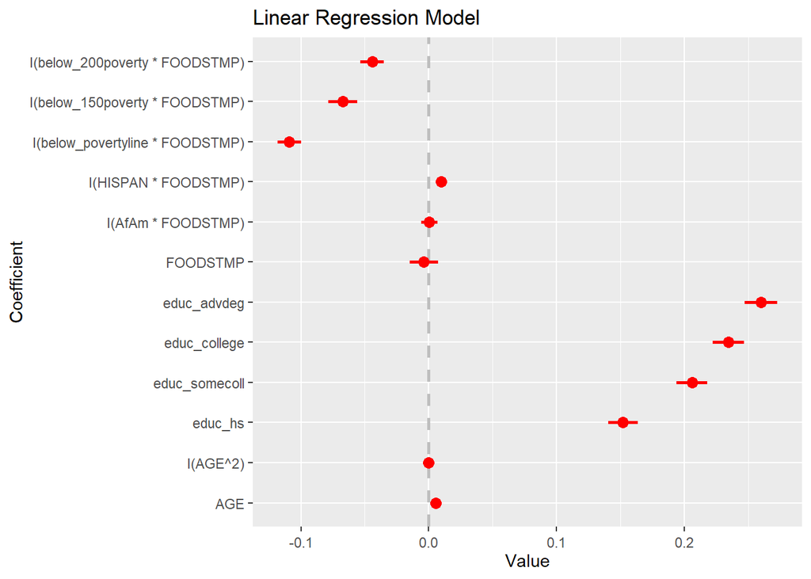

```r
model_ols2 <- lm(as.integer(LABFORCE) ~ AGE +  I(AGE^2) + educ_hs + educ_somecoll + educ_college + educ_advdeg + FOODSTMP + I(AfAm*FOODSTMP) + I(HISPAN*FOODSTMP) + I(below_povertyline*FOODSTMP) + I(below_150poverty*FOODSTMP) + I(below_200poverty*FOODSTMP), data = dat_use2)

#values for Labforce are 1 and 2

coefplot(model_ols2, innerCI=2, outerCI=0, intercept = FALSE, title = "Linear Regression Model", color = "red", lab = "Predictors")
```

```r
summary(model_ols2)
```

```
##
## Call:
## lm(formula = as.integer(LABFORCE) ~ AGE + I(AGE^2) + educ_hs +
##     educ_somecoll + educ_college + educ_advdeg + FOODSTMP + I(AfAm *
##     FOODSTMP) + I(HISPAN * FOODSTMP) + I(below_povertyline *
##     FOODSTMP) + I(below_150poverty * FOODSTMP) + I(below_200poverty *
##     FOODSTMP), data = dat_use2)
##
## Residuals:
##      Min       1Q   Median       3Q      Max
## -1.00670  0.05504  0.08924  0.16260  0.79211
##
## Coefficients:
##                                   Estimate Std. Error t value Pr(>|t|)
## (Intercept)                      1.602e+00  3.470e-02  46.180  < 2e-16 ***
## AGE                              5.300e-03  1.731e-03   3.062 0.002201 **
## I(AGE^2)                        -7.940e-05  2.142e-05  -3.706 0.000211 ***
## educ_hs                          1.520e-01  5.770e-03  26.349  < 2e-16 ***
## educ_somecoll                    2.060e-01  6.080e-03  33.881  < 2e-16 ***
## educ_college                     2.346e-01  6.120e-03  38.336  < 2e-16 ***
## educ_advdeg                      2.598e-01  6.340e-03  40.974  < 2e-16 ***
## FOODSTMP                        -3.859e-03  5.534e-03  -0.697 0.485527
## I(AfAm * FOODSTMP)               4.344e-04  3.154e-03   0.138 0.890445
## I(HISPAN * FOODSTMP)             9.830e-03  9.522e-04  10.323  < 2e-16 ***
## I(below_povertyline * FOODSTMP) -1.091e-01  4.555e-03 -23.958  < 2e-16 ***
## I(below_150poverty * FOODSTMP)  -6.732e-02  5.625e-03 -11.968  < 2e-16 ***
## I(below_200poverty * FOODSTMP)  -4.422e-02  4.571e-03  -9.674  < 2e-16 ***
## ---
## Signif. codes:  0 '***' 0.001 '**' 0.01 '*' 0.05 '.' 0.1 ' ' 1
##
## Residual standard error: 0.3486 on 66319 degrees of freedom
## Multiple R-squared:  0.1548, Adjusted R-squared:  0.1546
## F-statistic:  1012 on 12 and 66319 DF,  p-value: < 2.2e-16
```

```r
#Also estimate a probit model (details in Lecture Notes) and OLS, with the same X and Y variables. Compare the results, such as coefficients and predicted values. If you're eager, try to split the sample into training and test data, then compare which model predicts better in the sample that it hasn't seen yet

set.seed(654321)
NN <- length(dat_use2$LABFORCE)
restrict_1 <- (runif(NN) < 0.5)
summary(restrict_1)
```

```
##    Mode   FALSE    TRUE
## logical   33207   33125
```

```r
dat_train <- subset(dat_use2, restrict_1)
dat_test <- subset(dat_use2, !restrict_1)


model_probit5 <- glm(LABFORCE ~ AGE +  I(AGE^2) + educ_hs + educ_somecoll + educ_college + educ_advdeg + FOODSTMP + I(AfAm*FOODSTMP) + I(HISPAN*FOODSTMP) + I(below_povertyline*FOODSTMP) + I(below_150poverty*FOODSTMP) + I(below_200poverty*FOODSTMP), family = binomial (link= 'probit'), data = dat_train)

summary(model_probit5)
```

```
##
## Call:
## glm(formula = LABFORCE ~ AGE + I(AGE^2) + educ_hs + educ_somecoll +
##     educ_college + educ_advdeg + FOODSTMP + I(AfAm * FOODSTMP) +
##     I(HISPAN * FOODSTMP) + I(below_povertyline * FOODSTMP) +
##     I(below_150poverty * FOODSTMP) + I(below_200poverty * FOODSTMP),
##     family = binomial(link = "probit"), data = dat_train)
##
## Deviance Residuals:
##     Min       1Q   Median       3Q      Max
## -2.5147   0.3433   0.4511   0.5838   1.8701
##
## Coefficients:
##                                  Estimate Std. Error z value Pr(>|z|)
## (Intercept)                      0.289786   0.221829   1.306   0.1914
## AGE                              0.017385   0.011110   1.565   0.1176
## I(AGE^2)                        -0.000284   0.000137  -2.072   0.0383 *
## educ_hs                          0.439300   0.031065  14.141  < 2e-16 ***
## educ_somecoll                    0.679903   0.033788  20.123  < 2e-16 ***
## educ_college                     0.786198   0.034653  22.688  < 2e-16 ***
## educ_advdeg                      1.017231   0.038321  26.545  < 2e-16 ***
## FOODSTMP                         0.017118   0.032873   0.521   0.6026
## I(AfAm * FOODSTMP)              -0.002154   0.018738  -0.115   0.9085
## I(HISPAN * FOODSTMP)             0.033663   0.005789   5.815 6.06e-09 ***
## I(below_povertyline * FOODSTMP) -0.289608   0.024078 -12.028  < 2e-16 ***
## I(below_150poverty * FOODSTMP)  -0.188784   0.031650  -5.965 2.45e-09 ***
## I(below_200poverty * FOODSTMP)  -0.206020   0.027181  -7.580 3.46e-14 ***
## ---
## Signif. codes:  0 '***' 0.001 '**' 0.01 '*' 0.05 '.' 0.1 ' ' 1
##
## (Dispersion parameter for binomial family taken to be 1)
##
##     Null deviance: 30905  on 33124  degrees of freedom
## Residual deviance: 26449  on 33112  degrees of freedom
## AIC: 26475
##
## Number of Fisher Scoring iterations: 5
```

```r
pred_vals <- predict(model_probit5, dat_test, type = "response")
pred_model_probit5 <- (pred_vals > 0.5)
pred_table<-table(pred = pred_model_probit5, true = dat_test$LABFORCE)
pred_table
```

```
##        true
## pred    Not in LF in LF
##   FALSE      1206   840
##   TRUE       4486 26675
```

```r
print("Our model predicts labor force correctly with this percent accuracy when compared with the test data:")
```

```
## [1] "Our model predicts labor force correctly with this percent accuracy when compared with the test data:"
```

```r
paste0(round((pred_table[1,1]+pred_table[2,2])/sum(pred_table)*100,2), "%")
```

```
## [1] "83.96%"
```

Our model predicts correctly with 83.96% accuracy. This is slightly higher than the 82.6% of the population that is in the labor force.  
In this example we segmented the groups into both training and testing date to view the efficacy of our model.